# MAPPER Data Notebook Summer 2021

Francisco Huizar and Nilay Kumar University of Notre Dame Department of Chemical and Biomolecular Engineering Bioengineering Ph.D. Program, 4th year

# R setup and necessary packages for this code

Below are the function calls to setup the workspace and load packages necessary to run this script.

```r
rm(list=ls()) # Clear workspace
par(mfrow=c(1,1)) # Setup plot parameters
par(ps = 12, font.lab = 1) # Plot parameters
set.seed(1) # set random seed generator for reproducibility
knitr::opts_chunk$set(dev = c("svg"),
                      dpi = 300,
                      fig.path="MAPPER_Replicated_Figures/",
                      cache = TRUE,
                      comment = NA)
library(tidyverse)
#library(MASS)
#library(reshape2)
#library(pracma)
#library(olsrr)
#library(rcompanion)
#library(corrplot)
#library(ars)
#library(mvtnorm)
#library(coda)
#library(ggbiplot)
#library(Rtsne)
```

# Data import and pre-process

## Load the data

Load the data from the CSV file for wing measurements.

```r
dataset_df = read.csv("MAPPER_Data_New.csv", header=T, sep=",") %>% tibble()
grouped_by_species = group_by(dataset_df, Species)
grouped_by_species
```

| Metric | Filename | Gender | Species | Species_Gender | Measure |
| --- | --- | --- | --- | --- | --- |
| Area | 'a.tif' | Female | DA | DAF | 1.3510213 |
| Area | 'a1.tif' | Female | DA | DAF | 1.4588315 |
| Area | 'a2.tif' | Female | DA | DAF | 1.3955909 |
| Area | 'b.tif' | Female | DA | DAF | 1.4280014 |
| Area | 'c.tif' | Female | DA | DAF | 1.2742755 |
| Area | 'e.tif' | Female | DA | DAF | 1.4754324 |
| Area | 'f.tif' | Female | DA | DAF | 1.4699284 |
| Area | 'g.tif' | Female | DA | DAF | 1.2408641 |
| Area | 'i.tif' | Female | DA | DAF | 1.4054347 |
| Area | 'k.tif' | Female | DA | DAF | 1.4462817 |

[output cut: 846 more lines]

## Function for 95% median CI

Below is a function that calculates the exact confidence interval for a median from the DescTools package SignTest.default. The confidence interval is a non-parametric interval for the median using order statistics to deal directly with error on the median. More information can be found at http://www.stat.umn.edu/geyer/old03/5102/notes/rank.pdf and http://de.scribd.com/doc/75941305/Confidence-Interval-for-Median-Based-on-Sign-Test

```r
cimed <- function(x, alpha=0.05, na.rm=FALSE) {
  if(na.rm) x <- x[! is.na(x)]
  n <- length(x)
  k <- qbinom(p=alpha / 2, size=n, prob=0.5, lower.tail=TRUE)
  ## Actual CL: 1 - 2 * pbinom(k - 1, size=n, prob=0.5) >= 1 - alpha
  sort(x)[c(k, n - k + 1)]
}
```

# Generate Plots for Figure 5

## Figure 5B

Plotted is the total wing area for males and females (in $mm^2$) of the tested $\textit{Drosophila}$ species.

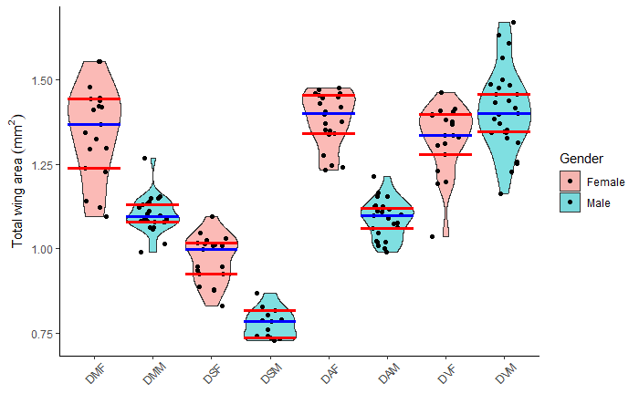

```r
plot_widths = 5.75
plot_heights = 3.25
plot_order = c("DMF","DMM","DSF","DSM","DAF","DAM","DVF","DVM")
#svg("Total_Area.svg", width = plot_widths, height = plot_heights, family="arial")
ggplot(grouped_by_species %>% dplyr::filter(Metric=="Area"),
       aes(x=factor(Species_Gender, ordered=TRUE, levels = plot_order),
           y=Measure,
           fill=Gender)) +
  geom_violin(scale="width", alpha=0.50) +
  geom_jitter(width=0.25) +
  stat_summary(fun="median", geom="crossbar", size=0.5, fill="red", color = "blue") +
  stat_summary(fun="cimed", geom="crossbar", size=0.5, fill="red", color = "red") +
  #theme(axis.text.x = element_text(angle = 45, vjust = 0.6),
  #      axis.title.x=element_blank(),
  #      axis.title.y=element_blank()) +

  theme(axis.text.x = element_text(angle = 45, vjust = 0.6),
        axis.title.x=element_blank()) +


  labs(x=expression(paste("")), y=expression(paste("Total wing area " (mm^2)))) +
  theme(panel.grid.major = element_blank(), panel.grid.minor = element_blank(),
panel.background = element_blank(), axis.line = element_line(colour = "black"))
```

## Figure 5C

Plotted is the quantification of shift in posterior cross vein position for males and females of the tested $\textit{Drosophila}$ species ($d_1$ is defined as the segment of $L_5$ from the proximal end of the vein to posterior cross vein, $d_2$ is defined as the segment of $L_5$ from the posterior cross vein to the distal end of $L_5$).

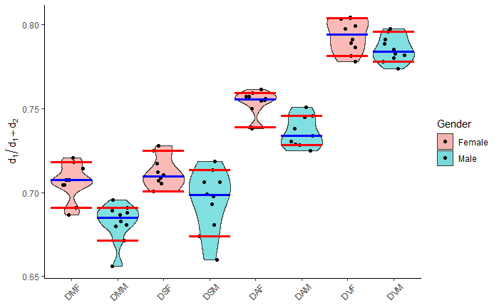

```r
plot_widths = 5.75
plot_heights = 3.25
plot_order = c("DMF","DMM","DSF","DSM","DAF","DAM","DVF","DVM")
#svg("Total_Area.svg", width = plot_widths, height = plot_heights, family="arial")
ggplot(grouped_by_species %>% dplyr::filter(Metric=="d1d2"),
       aes(x=factor(Species_Gender, ordered=TRUE, levels = plot_order),
           y=Measure,
           fill=Gender)) +
  geom_violin(scale="width", alpha=0.50) +
  geom_jitter(width=0.25) +
  stat_summary(fun="median", geom="crossbar", size=0.5, fill="red", color = "blue") +
  stat_summary(fun="cimed", geom="crossbar", size=0.5, fill="red", color = "red") +
  #theme(axis.text.x = element_text(angle = 45, vjust = 0.6),
  #      axis.title.x=element_blank(),
  #      axis.title.y=element_blank()) +

  theme(axis.text.x = element_text(angle = 45, vjust = 0.6),
        axis.title.x=element_blank()) +


  labs(x=expression(paste("")), y=expression(paste(d[1] / d[1]+d[2]))) +
  theme(panel.grid.major = element_blank(), panel.grid.minor = element_blank(),
panel.background = element_blank(), axis.line = element_line(colour = "black"))
```

## Figure 5D

Plotted are the relative anterior (A) and posterior (P) areas for males and females of the tested $\textit{Drosophila}$ species.

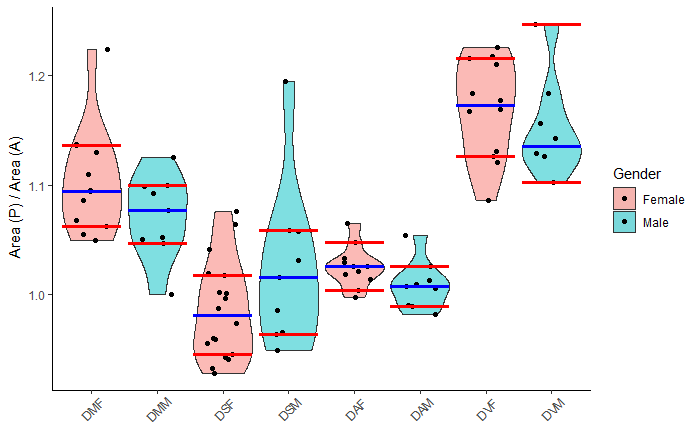

```r
plot_widths = 5.75
plot_heights = 3.25
plot_order = c("DMF","DMM","DSF","DSM","DAF","DAM","DVF","DVM")
#svg("Total_Area.svg", width = plot_widths, height = plot_heights, family="arial")
ggplot(grouped_by_species %>% dplyr::filter(Metric=="P_to_A"),
       aes(x=factor(Species_Gender, ordered=TRUE, levels = plot_order),
           y=Measure,
           fill=Gender)) +
  geom_violin(scale="width", alpha=0.50) +
  geom_jitter(width=0.25) +
  stat_summary(fun="median", geom="crossbar", size=0.5, fill="red", color = "blue") +
  stat_summary(fun="cimed", geom="crossbar", size=0.5, fill="red", color = "red") +
  #theme(axis.text.x = element_text(angle = 45, vjust = 0.6),
  #      axis.title.x=element_blank(),
  #      axis.title.y=element_blank()) +

  theme(axis.text.x = element_text(angle = 45, vjust = 0.6),
        axis.title.x=element_blank()) +


  labs(x=expression(paste("")), y=expression(paste("Area (P) / Area (A)"))) +
  theme(panel.grid.major = element_blank(), panel.grid.minor = element_blank(),
panel.background = element_blank(), axis.line = element_line(colour = "black"))
```

## Figure 5D Anterior Only

Plotted are the anterior areas for males and females (in $mm^2$) of the tested $\textit{Drosophila}$ species.

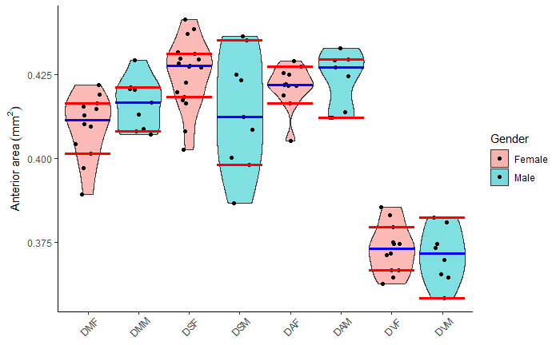

```r
plot_widths = 5.75
plot_heights = 3.25
plot_order = c("DMF","DMM","DSF","DSM","DAF","DAM","DVF","DVM")
#svg("Total_Area.svg", width = plot_widths, height = plot_heights, family="arial")
ggplot(grouped_by_species %>% dplyr::filter(Metric=="Anterior_Area"),
       aes(x=factor(Species_Gender, ordered=TRUE, levels = plot_order),
           y=Measure,
           fill=Gender)) +
  geom_violin(scale="width", alpha=0.50) +
  geom_jitter(width=0.25) +
  stat_summary(fun="median", geom="crossbar", size=0.5, fill="red", color = "blue") +
  stat_summary(fun="cimed", geom="crossbar", size=0.5, fill="red", color = "red") +
  #theme(axis.text.x = element_text(angle = 45, vjust = 0.6),
  #      axis.title.x=element_blank(),
  #      axis.title.y=element_blank()) +

  theme(axis.text.x = element_text(angle = 45, vjust = 0.6),
        axis.title.x=element_blank()) +


  labs(x=expression(paste("")), y=expression(paste("Anterior area " (mm^2)))) +
  theme(panel.grid.major = element_blank(), panel.grid.minor = element_blank(),
panel.background = element_blank(), axis.line = element_line(colour = "black"))
```

## Figure 5D Posterior Only

Plotted are the posterior areas for males and females (in $mm^2$) of the tested $\textit{Drosophila}$ species.

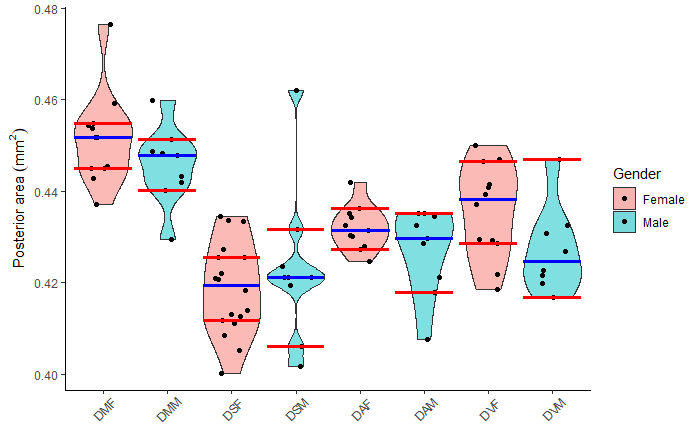

```r
plot_widths = 5.75
plot_heights = 3.25
plot_order = c("DMF","DMM","DSF","DSM","DAF","DAM","DVF","DVM")
#svg("Total_Area.svg", width = plot_widths, height = plot_heights, family="arial")
ggplot(grouped_by_species %>% dplyr::filter(Metric=="Posterior_Area"),
       aes(x=factor(Species_Gender, ordered=TRUE, levels = plot_order),
           y=Measure,
           fill=Gender)) +
  geom_violin(scale="width", alpha=0.50) +
  geom_jitter(width=0.25) +
  stat_summary(fun="median", geom="crossbar", size=0.5, fill="red", color = "blue") +
  stat_summary(fun="cimed", geom="crossbar", size=0.5, fill="red", color = "red") +
  #theme(axis.text.x = element_text(angle = 45, vjust = 0.6),
  #      axis.title.x=element_blank(),
  #      axis.title.y=element_blank()) +

  theme(axis.text.x = element_text(angle = 45, vjust = 0.6),
        axis.title.x=element_blank()) +


  labs(x=expression(paste("")), y=expression(paste("Posterior area " (mm^2)))) +
  theme(panel.grid.major = element_blank(), panel.grid.minor = element_blank(),
panel.background = element_blank(), axis.line = element_line(colour = "black"))
```

## Figure 5E

Plotted are the scaling relationships between the length of the proximal-distal (l(P-D)) axis and the square root overall wing blade area for males and females of the tested $\textit{Drosophila}$ species.

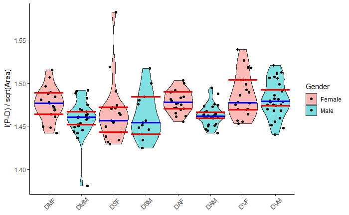

```r
plot_widths = 5.75
plot_heights = 3.25
plot_order = c("DMF","DMM","DSF","DSM","DAF","DAM","DVF","DVM")
#svg("Total_Area.svg", width = plot_widths, height = plot_heights, family="arial")
PD_Only = grouped_by_species%>%dplyr::filter(Metric=="PD")
Area_Only = grouped_by_species%>%dplyr::filter(Metric=="Area")
ggplot(Area_Only,
       aes(x=factor(Species_Gender, ordered=TRUE, levels = plot_order),
           y=PD_Only$Measure / sqrt(Area_Only$Measure),
           fill=Gender)) +
  geom_violin(scale="width", alpha=0.50) +
  geom_jitter(width=0.25) +
  stat_summary(fun="median", geom="crossbar", size=0.5, fill="red", color = "blue") +
  stat_summary(fun="cimed", geom="crossbar", size=0.5, fill="red", color = "red") +
  #theme(axis.text.x = element_text(angle = 45, vjust = 0.6),
  #      axis.title.x=element_blank(),
  #      axis.title.y=element_blank()) +

  theme(axis.text.x = element_text(angle = 45, vjust = 0.6),
        axis.title.x=element_blank()) +


  labs(x=expression(paste("")), y=expression(paste("l(P-D) / sqrt(Area)"))) +
  theme(panel.grid.major = element_blank(), panel.grid.minor = element_blank(),
panel.background = element_blank(), axis.line = element_line(colour = "black"))
```

## Figure 5F

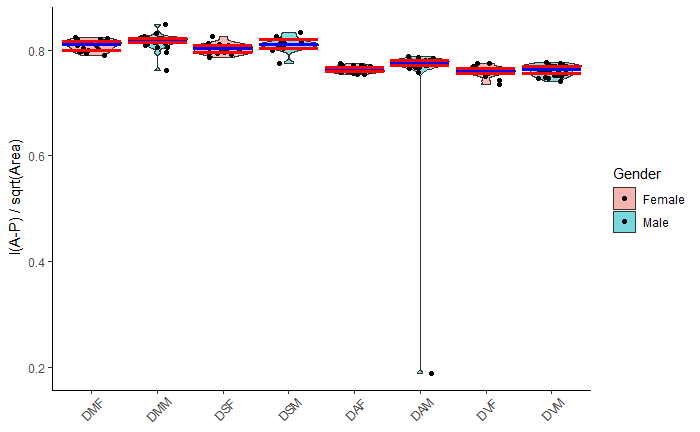

```r
plot_widths = 5.75
plot_heights = 3.25
plot_order = c("DMF","DMM","DSF","DSM","DAF","DAM","DVF","DVM")
#svg("Total_Area.svg", width = plot_widths, height = plot_heights, family="arial")
AP_Only = grouped_by_species%>%dplyr::filter(Metric=="AP")
Area_Only = grouped_by_species%>%dplyr::filter(Metric=="Area")
ggplot(Area_Only,
       aes(x=factor(Species_Gender, ordered=TRUE, levels = plot_order),
           y=AP_Only$Measure / sqrt(Area_Only$Measure),
           fill=Gender)) +
  geom_violin(scale="width", alpha=0.50) +
  geom_jitter(width=0.25) +
  stat_summary(fun="median", geom="crossbar", size=0.5, fill="red", color = "blue") +
  stat_summary(fun="cimed", geom="crossbar", size=0.5, fill="red", color = "red") +
  #theme(axis.text.x = element_text(angle = 45, vjust = 0.6),
  #      axis.title.x=element_blank(),
  #      axis.title.y=element_blank()) +

  theme(axis.text.x = element_text(angle = 45, vjust = 0.6),
        axis.title.x=element_blank()) +


  labs(x=expression(paste("")), y=expression(paste("l(A-P) / sqrt(Area)"))) +
  theme(panel.grid.major = element_blank(), panel.grid.minor = element_blank(),
panel.background = element_blank(), axis.line = element_line(colour = "black"))
```

## Figure 5G

Plotted are the l(P-D) to l(A-P) ratio for males and females of the tested $\textit{Drosophila}$ species. **OUTLIER NEEDS TO BE ADDRESSED**

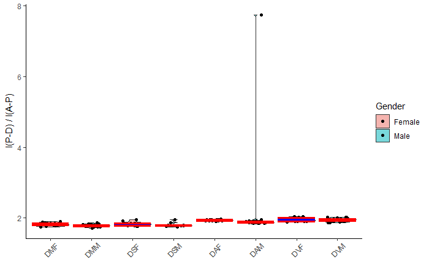

```r
plot_widths = 5.75
plot_heights = 3.25
plot_order = c("DMF","DMM","DSF","DSM","DAF","DAM","DVF","DVM")
#svg("Total_Area.svg", width = plot_widths, height = plot_heights, family="arial")
ggplot(Area_Only,
       aes(x=factor(Species_Gender, ordered=TRUE, levels = plot_order),
           y=PD_Only$Measure / AP_Only$Measure,
           fill=Gender)) +
  geom_violin(scale="width", alpha=0.50) +
  geom_jitter(width=0.25) +
  stat_summary(fun="median", geom="crossbar", size=0.5, fill="red", color = "blue") +
  stat_summary(fun="cimed", geom="crossbar", size=0.5, fill="red", color = "red") +
  #theme(axis.text.x = element_text(angle = 45, vjust = 0.6),
  #      axis.title.x=element_blank(),
  #      axis.title.y=element_blank()) +

  theme(axis.text.x = element_text(angle = 45, vjust = 0.6),
        axis.title.x=element_blank()) +


  labs(x=expression(paste("")), y=expression(paste("l(P-D) / l(A-P)"))) +
  theme(panel.grid.major = element_blank(), panel.grid.minor = element_blank(),
panel.background = element_blank(), axis.line = element_line(colour = "black"))
```

**NEED TO OBTAIN MISSING DATA FROM NILAY**

# Manual versus automated measurements of wing area and landmark positions

## Load second dataset

Load the CSV file containing the data.

```r
dataset_df_comparison = read.csv("MAPPER_Manual_VS_Automated.csv", header=T, sep=",", fileEncoding="UTF-8-BOM") %>% tibble()
dataset_df_comparison
```

| Manual_File | Manual_Area | Manual_PD | Manual_AP | Auto_File | Auto_Area | Auto_PD | Auto_AP |
| --- | --- | --- | --- | --- | --- | --- | --- |
| samw_M_L_oly_4X_2 | 23.192 | 6.77 | 4.01 | samw_M_L_oly_4X_2 | 483812 | 956.0598 | 565.5528 |
| samw_M_L_oly_4X_3 | 23.060 | 6.72 | 3.98 | samw_M_L_oly_4X_3 | 480908 | 943.2255 | 567.4170 |
| samw_M_L_oly_4X_4 | 18.801 | 6.13 | 3.56 | samw_M_L_oly_4X_4 | 393223 | 857.1851 | 509.5194 |
| samw_M_L_oly_4X_5 | 21.592 | 6.51 | 3.82 | samw_M_L_oly_4X_5 | 451018 | 824.3199 | 543.3231 |
| samw_M_L_oly_4X_6 | 22.201 | 6.69 | 3.91 | samw_M_L_oly_4X_6 | 460920 | 939.4259 | 552.4898 |
| samw_M_L_oly_4X_7 | 23.267 | 6.75 | 3.99 | samw_M_L_oly_4X_7 | 484991 | 957.6623 | 561.5870 |
| samw_M_L_oly_4X_9 | 22.839 | 6.69 | 3.97 | samw_M_L_oly_4X_9 | 479705 | 951.6475 | 560.4400 |
| samw_M_L_oly_4X_10 | 22.478 | 6.62 | 3.91 | samw_M_L_oly_4X_10 | 472624 | 947.2563 | 555.1549 |
| samw_M_L_oly_4X_11 | 23.968 | 6.61 | 3.98 | samw_M_L_oly_4X_11 | 499511 | 972.5703 | 563.5495 |
| samw_M_L_oly_4X_12 | 23.895 | 6.80 | 3.99 | samw_M_L_oly_4X_12 | 502853 | 973.2894 | 567.8345 |

[output cut: 56 more lines]

## Ensure no mismatches names/labels in files

Here, the file names of manual measurements are compared to automated measurements and check for any labelling mismatches. A value of zero returned indicates no mismatches.

```r
sum(dataset_df_comparison$Manual_File != dataset_df_comparison$Auto_File)
```

```
[1] 0
```

## Plot the areas

Plotted are the total wing areas of male Samarkand species $\textit{Drosophila}$ that were measured manually and by MAPPER. The two are plotted against each other to demonstrate a 1:1 correlation. **UNITS NEED TO BE FIXED**

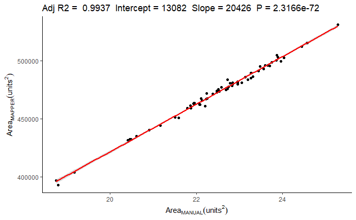

```r
plot_widths = 5.75
plot_heights = 3.25
#svg("Total_Area.svg", width = plot_widths, height = plot_heights, family="arial")
linear_fit = lm(dataset_df_comparison$Auto_Area~dataset_df_comparison$Manual_Area)
ggplot(dataset_df_comparison,
       aes(x=Manual_Area,
           y=Auto_Area)) +
  geom_point() +
  stat_smooth(method = "lm", col = "red", formula = y~x) +
  labs(x=expression(paste(Area[MANUAL] (units^2))),
       y=expression(paste(Area[MAPPER] (units^2))),
       title = paste("Adj R2 = ",signif(summary(linear_fit)$adj.r.squared, 5),
                     " Intercept =",signif(linear_fit$coef[[1]],5 ),
                     " Slope =",signif(linear_fit$coef[[2]], 5),
                     " P =",signif(summary(linear_fit)$coef[2,4], 5))) +
  theme(panel.grid.major = element_blank(), panel.grid.minor = element_blank(),
panel.background = element_blank(), axis.line = element_line(colour = "black"))
```

The summary statistics of the linear fit are shown below:

```r
summary(linear_fit)
```

```
Call:
lm(formula = dataset_df_comparison$Auto_Area ~ dataset_df_comparison$Manual_Area)

Residuals:
    Min      1Q  Median      3Q     Max
-5648.5 -1264.9    49.5  1382.0  6277.4

Coefficients:
                                  Estimate Std. Error t value Pr(>|t|)
(Intercept)                        13081.5     4552.4   2.874   0.0055 **
dataset_df_comparison$Manual_Area  20426.4      201.7 101.249   <2e-16 ***
---
Signif. codes:  0 ‘***’ 0.001 ‘**’ 0.01 ‘*’ 0.05 ‘.’ 0.1 ‘ ’ 1

Residual standard error: 2097 on 64 degrees of freedom
Multiple R-squared:  0.9938,    Adjusted R-squared:  0.9937
F-statistic: 1.025e+04 on 1 and 64 DF,  p-value: < 2.2e-16
```

## Plot the l(P-D)

Plotted are the lengths of the proximal-distal (l(P-D)) axes for male Samarkand species $\textit{Drosophila}$ that were measured manually and by MAPPER. The two are plotted against each other to demonstrate a 1:1 correlation. **UNITS NEED TO BE FIXED AND THERE IS A NOTALBE MISMATCH**

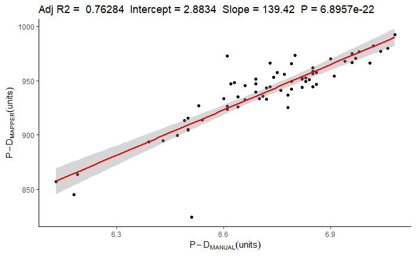

```r
plot_widths = 5.75
plot_heights = 3.25
#svg("Total_Area.svg", width = plot_widths, height = plot_heights, family="arial")
linear_fit = lm(dataset_df_comparison$Auto_PD~dataset_df_comparison$Manual_PD)
ggplot(dataset_df_comparison,
       aes(x=Manual_PD,
           y=Auto_PD)) +
  geom_point() +
  stat_smooth(method = "lm", col = "red", formula = y~x) +
  labs(x=expression(paste(P-D[MANUAL] (units))),
       y=expression(paste(P-D[MAPPER] (units))),
       title = paste("Adj R2 = ",signif(summary(linear_fit)$adj.r.squared, 5),
                     " Intercept =",signif(linear_fit$coef[[1]],5 ),
                     " Slope =",signif(linear_fit$coef[[2]], 5),
                     " P =",signif(summary(linear_fit)$coef[2,4], 5))) +
  theme(panel.grid.major = element_blank(), panel.grid.minor = element_blank(),
panel.background = element_blank(), axis.line = element_line(colour = "black"))
```

The summary statistics of the linear fit are shown below:

```r
summary(linear_fit)
```

```
Call:
lm(formula = dataset_df_comparison$Auto_PD ~ dataset_df_comparison$Manual_PD)

Residuals:
    Min      1Q  Median      3Q     Max
-86.174  -4.981  -0.873   5.366  48.135

Coefficients:
                                Estimate Std. Error t value Pr(>|t|)
(Intercept)                        2.883     64.691   0.045    0.965
dataset_df_comparison$Manual_PD  139.418      9.619  14.494   <2e-16 ***
---
Signif. codes:  0 ‘***’ 0.001 ‘**’ 0.01 ‘*’ 0.05 ‘.’ 0.1 ‘ ’ 1

Residual standard error: 15.72 on 64 degrees of freedom
Multiple R-squared:  0.7665,    Adjusted R-squared:  0.7628
F-statistic: 210.1 on 1 and 64 DF,  p-value: < 2.2e-16
```

## Plot the l(A-P)

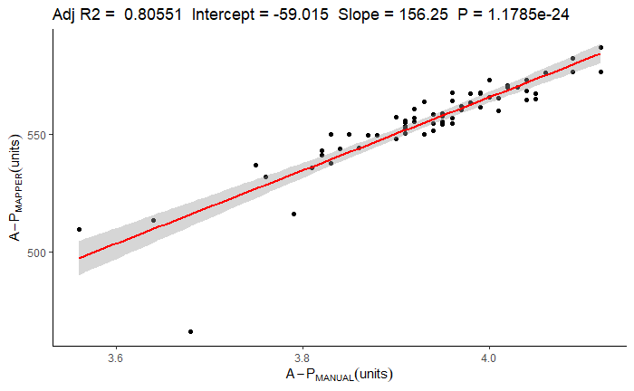

```r
plot_widths = 5.75
plot_heights = 3.25
#svg("Total_Area.svg", width = plot_widths, height = plot_heights, family="arial")
linear_fit = lm(dataset_df_comparison$Auto_AP~dataset_df_comparison$Manual_AP)
ggplot(dataset_df_comparison,
       aes(x=Manual_AP,
           y=Auto_AP)) +
  geom_point() +
  stat_smooth(method = "lm", col = "red", formula = y~x) +
  labs(x=expression(paste(A-P[MANUAL] (units))),
       y=expression(paste(A-P[MAPPER] (units))),
       title = paste("Adj R2 = ",signif(summary(linear_fit)$adj.r.squared, 5),
                     " Intercept =",signif(linear_fit$coef[[1]],5 ),
                     " Slope =",signif(linear_fit$coef[[2]], 5),
                     " P =",signif(summary(linear_fit)$coef[2,4], 5))) +
  theme(panel.grid.major = element_blank(), panel.grid.minor = element_blank(),
panel.background = element_blank(), axis.line = element_line(colour = "black"))
```

The summary statistics of the linear fit are shown below:

```r
summary(linear_fit)
```

```
Call:
lm(formula = dataset_df_comparison$Auto_AP ~ dataset_df_comparison$Manual_AP)

Residuals:
    Min      1Q  Median      3Q     Max
-50.225  -2.465   0.998   3.548  12.276

Coefficients:
                                Estimate Std. Error t value Pr(>|t|)
(Intercept)                      -59.015     37.384  -1.579    0.119
dataset_df_comparison$Manual_AP  156.252      9.506  16.438   <2e-16 ***
---
Signif. codes:  0 ‘***’ 0.001 ‘**’ 0.01 ‘*’ 0.05 ‘.’ 0.1 ‘ ’ 1

Residual standard error: 8.133 on 64 degrees of freedom
Multiple R-squared:  0.8085,    Adjusted R-squared:  0.8055
F-statistic: 270.2 on 1 and 64 DF,  p-value: < 2.2e-16
```

# **TO DO:**

- Fix units for plots of Figure 4
- Obtain L3-L4 area measurements for Figure 5 panel H
- Address the outlier in Figure 5F and 5G
- Provide statistical comparisons of groups
- Have table of p-value comparisons